# Soil Domestication

Joe Edwards

## Introductions

Here in this experiment, we have grown rice plants in soils from rice fields and from locations that are adjacent to rice fields, but are not growing crops. The goal was to see if there are consistent differences between the microbiomes that rice plants assemble from these soils.

## Load in the libraries

Note that this analysis relies on the tidyMB package. This can be found on my github profile.

```r
library(vegan)
library(tidyverse)
library(broom)
library(biobroom)
library(tidyMB)
library(DESeq2)
```

## Betadiversity

First things first. What is the underlying structure of the data?

```r
dPC <- tidy_pcoa(dExp %>% mutate(RA = RA*1000), dist = "bray", value = "RA", keep_loadings = F)
```

```
Gathering metadata
Removing the column variable from the metadata.
Converting to wide table.
```

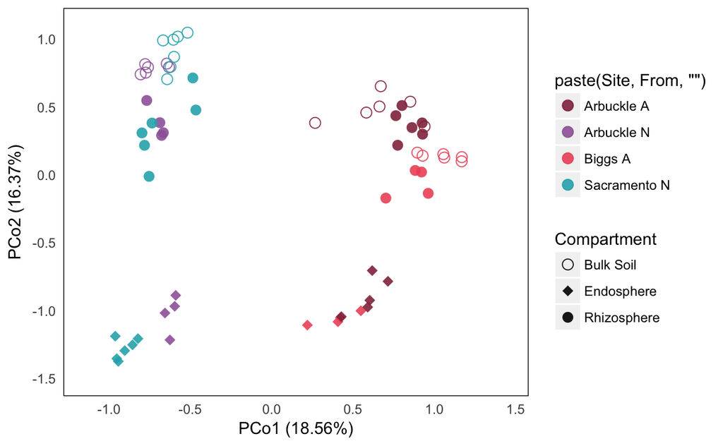

```r
dPC_plot <- dPC$axes %>%
  ggplot(aes(MDS1, MDS2, color = paste(Site, From, ""), shape = Compartment)) +
  geom_point(size = 3, alpha = 0.9) +
  scale_color_manual(values = c("#92324B","#9e66a7",'#ee5768', '#27afb9')) +
  labs(x = paste("PCo1 (", round(dPC$eigen_vals[1] * 100, 2), "%)", sep = ""), y = paste("PCo2 (", round(dPC$eigen_vals[2] * 100, 2), "%)", sep = "")) +
  scale_shape_manual(values = c(1, 18, 16)) +
  lims(x = c(-1.15, 1.45), y = c(-1.5, 1.1)) +
  theme(panel.background = element_rect(fill = "white"),
        panel.border = element_rect(fill = NA),
        axis.ticks.x = element_blank(),
        axis.ticks.y = element_blank())
dPC_plot
```

```r
dExp %>%
  mutate(logRA = log2(RA * 1000 + 1)) %>%
  long_adonis(., value = "logRA", formula = "Compartment * From + Experiment") %>% tidy(.)
```

```
Gathering metadata
Removing the column variable from the metadata.
Converting to wide table.
The following column names in ANOVA output were not recognized or transformed: SumsOfSqs, MeanSqs, F.Model, R2
```

| term | df | SumsOfSqs | MeanSqs | F.Model | R2 | p.value |
| --- | --- | --- | --- | --- | --- | --- |
| Compartment | 2 | 3.930259 | 1.9651295 | 14.034323 | 0.21575021 | 0.001 |
| From | 1 | 3.156912 | 3.1569123 | 22.545653 | 0.17329762 | 0.001 |
| Experiment | 1 | 2.003977 | 2.0039773 | 14.311762 | 0.11000765 | 0.001 |
| Compartment:From | 2 | 1.144244 | 0.5721219 | 4.085911 | 0.06281287 | 0.001 |
| Residuals | 57 | 7.981317 | 0.1400231 | NA | 0.43813165 | NA |
| Total | 63 | 18.216709 | NA | NA | 1.00000000 | NA |

```r
dExp %>%
  mutate(logRA = log2(RA * 1000 + 1)) %>%
  mutate(Compartment = fct_relevel(factor(Compartment), "Bulk Soil", "Rhizosphere", "Endosphere")) %>%
  group_by(Compartment) %>%
  nest() %>%
  mutate(adon = map(data, ~long_adonis(., value = "logRA", formula = "From + Experiment"))) %>%
  unnest(map(adon, ~tidy(.)))
```

[output not shown]

| Compartment | term | df | SumsOfSqs | MeanSqs | F.Model | R2 | p.value |
| --- | --- | --- | --- | --- | --- | --- | --- |
| Rhizosphere | From | 1 | 1.2602654 | 1.2602654 | 11.796123 | 0.3230150 | 0.001 |
| Rhizosphere | Experiment | 1 | 0.8250705 | 0.8250705 | 7.722685 | 0.2114714 | 0.001 |
| Rhizosphere | Residuals | 17 | 1.8162333 | 0.1068373 | NA | 0.4655135 | NA |
| Rhizosphere | Total | 19 | 3.9015692 | NA | NA | 1.0000000 | NA |
| Endosphere | From | 1 | 1.3629566 | 1.3629566 | 8.964228 | 0.3047126 | 0.001 |
| Endosphere | Experiment | 1 | 0.6772657 | 0.6772657 | 4.454407 | 0.1514145 | 0.001 |
| Endosphere | Residuals | 16 | 2.4327033 | 0.1520440 | NA | 0.5438730 | NA |
| Endosphere | Total | 18 | 4.4729257 | NA | NA | 1.0000000 | NA |
| Bulk Soil | From | 1 | 1.6786907 | 1.6786907 | 13.810858 | 0.2839485 | 0.001 |
| Bulk Soil | Experiment | 1 | 1.5591953 | 1.5591953 | 12.827750 | 0.2637360 | 0.001 |

[output cut: 2 more lines]

Let’s compare the mean dispersion around the centroid for every compartment and soil type. One could imagine that if rice is “domesticating” a soil, then the rice soils would have less variability than the wild soils because the rice soil is under a similar set of conditions while the wild soils might face more dissimilar conditions.

```r
dBetaDisp <- dExp %>%
  ungroup() %>%
  mutate(group = paste(From, Compartment, sep = "_")) %>%
  mutate(logRA = log2(RA * 1000 + 1)) %>%
  tidyMB::tidy_betadisper(., value = "logRA", group = "group")
```

```
Gathering metadata
Removing the column variable from the metadata.
Converting to wide table.
```

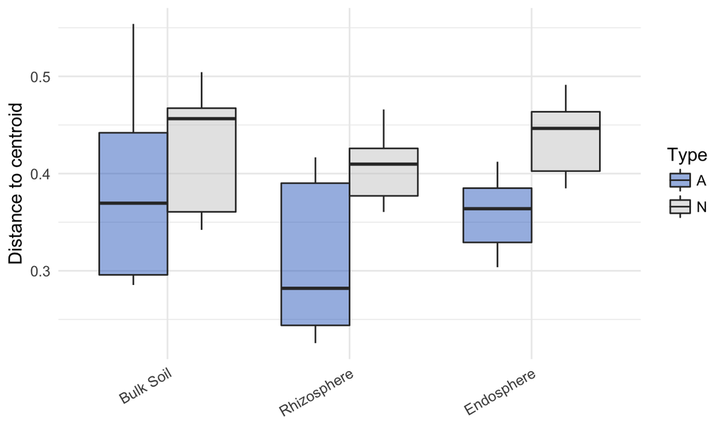

```r
data.frame(group_var = dBetaDisp$group, distance = dBetaDisp$distances) %>%
  separate(group_var, into = c("Type", "Compartment"), sep = "_") %>%
  mutate(Compartment  = fct_relevel(factor(Compartment), "Bulk Soil", "Rhizosphere", "Endosphere")) %>%
  ggplot(., aes(x = Compartment, y = distance, fill = Type)) +
  geom_boxplot(alpha = 0.5) +
  theme_minimal() +
  labs(x = "", y = "Distance to centroid") +
  scale_fill_manual(values = c("#3771c8", "grey80")) +
  theme(axis.text.x = element_text(angle = 30, hjust = 1), text = element_text(size = 12))
```

## Comparing rhizosphere to bulk soil distances

Remember that result where the rice rhizosphere is significantly more similar to the bulk soil microbiome than the rhizosphere microbiomes from the native plants? One of the hypotheses that came from that was that rice may be “domesticating” the soil microbiome. If you go to rice field, you will quickly realize that those plants are growing so closely together that, at some point in the season, all of the roots will overlap and the top layer of soil is only composed of rhizosphere. We can test this hypothesis by growing rice plants in soil from rice fields and soil from uncultivated sites. In order to support this hypothesis that rice is “domesticating” field soil, we need to show a few things. One is that the distance between rhizospehre and bulk soil is greater in the “wild” soils. The other is that the rhizospheres of rice plants growing in wild and domesticated soils are mmore similar than the bulk soils.

```r
d_dist <- dExp %>%
  long_distance(.)
```

```
Gathering metadata
Removing the column variable from the metadata.
Converting to wide table.
Column `Var1`/`SampleID` joining factor and character vector, coercing into character vectorColumn `Var2`/`SampleID` joining factor and character vector, coercing into character vector
```

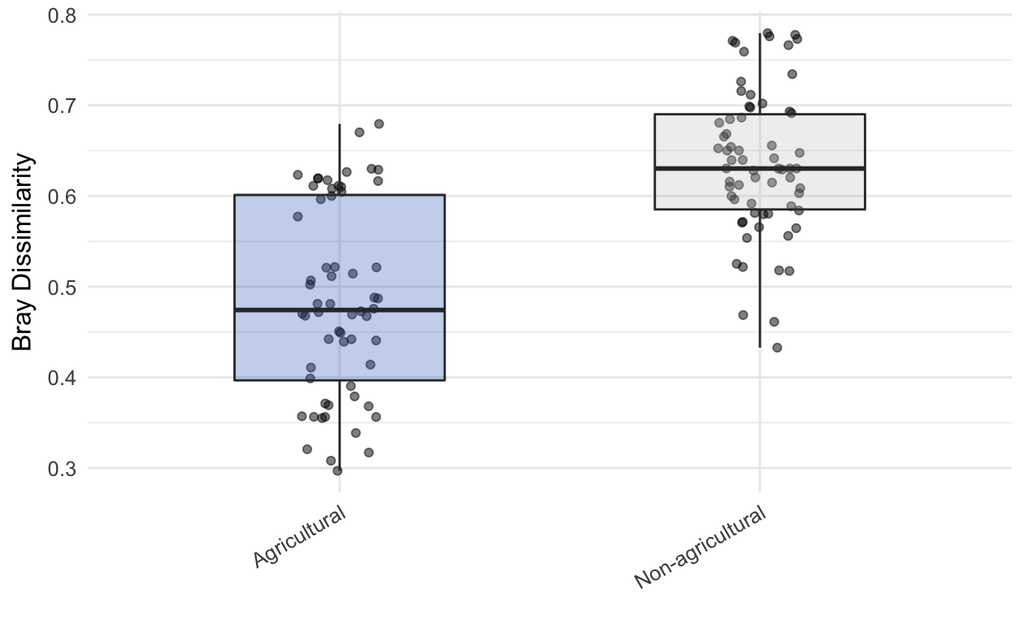

```r
rs_vs_bs <- d_dist %>%
  filter(Compartment.x%in%c("Rhizosphere", "Bulk Soil")) %>%
  filter(Compartment.y%in%c("Rhizosphere", "Bulk Soil")) %>%
  filter(Compartment.x != Compartment.y) %>%
  filter(From.x == From.y) %>%
  filter(Experiment.x == Experiment.y) %>%
  mutate(From = ifelse(From.x == "A", "Agricultural", "Non-agricultural"))
rs_vs_bs_plot <- rs_vs_bs %>%
  ggplot(aes(From, value, fill = From)) +
  geom_jitter(width = 0.1, height = 0, alpha = 0.5) +
  geom_boxplot(alpha = 0.3, width = 0.5) +
  #geom_violin() +
  scale_fill_manual(values = c("#3771c8", "grey80")) +
  scale_shape_manual(values = c(1,4)) +
  theme_minimal() +
  labs(x = "", y = "Bray Dissimilarity") +
  theme(text = element_text(size =12), legend.position = "none", axis.text.x = element_text(angle = 30, hjust = 1))
rs_vs_bs_plot
```

The above plot appears to support my suspicion that rice plants growing in agricultural soil host a rhizosphere microbiome that is more similar to their corresponding bulk soils. Let’s do some statistics to make sure these differences are “signficant”.

```r
tidy(lm(value ~ From.x, data = rs_vs_bs))
```

| term | estimate | std.error | statistic | p.value |
| --- | --- | --- | --- | --- |
| (Intercept) | 0.4851845 | 0.01200179 | 40.426021 | 2.930339e-73 |
| From.xN | 0.1507541 | 0.01658285 | 9.090961 | 1.979035e-15 |

```r
rs_vs_bs %>%
  group_by(Experiment.x) %>%
  nest() %>%
  mutate(mod = map(data, ~lm(value ~ From.x, .))) %>%
  unnest(map(mod, ~tidy(.)))
```

| Experiment.x | term | estimate | std.error | statistic | p.value |
| --- | --- | --- | --- | --- | --- |
| Transplant | (Intercept) | 0.55414477 | 0.01482333 | 37.383287 | 4.484456e-36 |
| Transplant | From.xN | 0.08775942 | 0.02096335 | 4.186325 | 1.265494e-04 |
| Mix | (Intercept) | 0.43921101 | 0.01526488 | 28.772649 | 1.311117e-42 |
| Mix | From.xN | 0.19331867 | 0.02080252 | 9.293039 | 3.673405e-14 |

Cool Cool. Looks lik this trend is significant. Let’s compare the rhizospheres to see if they are more similar.

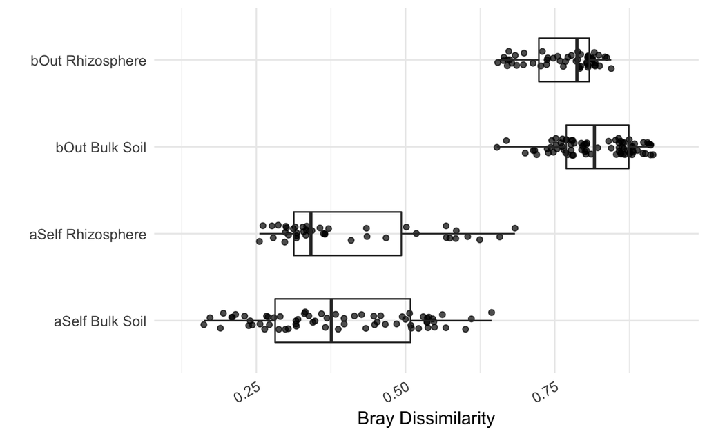

```r
same_comps <- d_dist %>%
  filter(Compartment.x%in%c("Rhizosphere", "Bulk Soil")) %>%
  filter(Compartment.y%in%c("Rhizosphere", "Bulk Soil")) %>%
  filter(Compartment.x == Compartment.y) %>%
  filter(Experiment.x == Experiment.y) %>%
  mutate(type = ifelse(From.y == From.x, "aSelf", "bOut"))
same_comps_plot <- same_comps %>%
  ggplot(aes(paste(type, Compartment.x), value)) +
  geom_jitter(width = 0.1, alpha = 0.7) +
  geom_boxplot(alpha = 0, width = 0.5) +
  #facet_wrap(~type, scales = "free") +
  scale_shape_manual(values = c(1,4)) +
  theme_minimal() +
  lims(y = c(0.12, 0.95)) +
  labs(x = "", y = "Bray Dissimilarity") +
  theme(axis.text.x = element_text(angle = 30, hjust = 1), text = element_text(size = 12))
same_comps_plot + coord_flip()
```

```r
same_comps %>%
  group_by(type) %>%
  nest() %>%
  mutate(mod = map(data, ~lm(value ~ Compartment.x, .))) %>%
  unnest(map(mod, ~tidy(.)))
```

| type | term | estimate | std.error | statistic | p.value |
| --- | --- | --- | --- | --- | --- |
| aSelf | (Intercept) | 0.38829088 | 0.015573133 | 24.9333819 | 3.804863e-46 |
| aSelf | Compartment.xRhizosphere | 0.01204539 | 0.024972570 | 0.4823447 | 6.305557e-01 |
| bOut | (Intercept) | 0.81920945 | 0.006954948 | 117.7880041 | 2.263060e-132 |
| bOut | Compartment.xRhizosphere | -0.05575146 | 0.010996738 | -5.0698177 | 1.362363e-06 |

## Differentially abundant OTUs

We see relatively large differences between “domesticated” and “wild” soils. Let’s find the OTUs that explain these differences.

```r
## I'm going to run this, and then save the results to I don't have to do it again.
 dom_deseq <- dExp %>%
   group_by(variable) %>%
   filter(sum(value > 0) / n() > 0.1) %>%
   mutate(group = paste(Compartment, From, sep = ".")) %>%
   group_by(group_var = "DESeq2", Experiment) %>%
   nest() %>%
   mutate(DGEL = map(data, ~suppressMessages(tidyDGEL(., value = "value", group_column = "group", method = "DESeq2", formula = "~ group")))) %>%
   mutate(dds = map(DGEL, ~suppressMessages(DESeq(.)))) %>%
   mutate(BulkSoil = map(dds, ~lfcShrink(., contrast = c("group", "Bulk Soil.A", "Bulk Soil.N")))) %>%
   mutate(Rhizosphere = map(dds, ~lfcShrink(., contrast = c("group", "Rhizosphere.A", "Rhizosphere.N")))) %>%
   mutate(Endosphere = map(dds, ~lfcShrink(., contrast = c("group", "Endosphere.A", "Endosphere.N")))) %>%
   dplyr::select(BulkSoil, Rhizosphere, Endosphere, Experiment) %>%
   gather(key = Compartment, value = results, -Experiment)
```

```
Removing the column variable from the metadata.
some variables in design formula are characters, converting to factorsRemoving the column variable from the metadata.
some variables in design formula are characters, converting to factors
```

```r
 dom_deseq %>%
   ungroup() %>%
   write_rds(path = "~/RMB/SoilDomestication/Data/domestication_deseq.rds")
#dom_deseq <- readRDS("~/RMB/SoilDomestication/Data/domestication_deseq.rds")
```

```r
dom_otus <- dom_deseq %>%
  unnest(map(results, ~tidy(.))) %>%
  group_by(Experiment, Compartment) %>%
  mutate(direction = ifelse(estimate > 0, "A", "N")) %>%
  filter(p.adjusted <= 0.05) %>% ungroup() %>%
  dplyr::count(direction, Compartment, gene) %>%
  filter(n == 2) %>%
  dplyr::count(direction, gene, Compartment) %>%
  dplyr::rename(variable = gene)
np_deseq <- read_rds("~/RMB/SoilDomestication/Data/weeds_deseq.rds")
rice_otus <- np_deseq %>%
  unnest(map(results, ~tidy(.))) %>%
  separate(taxon, sep = "_", into = c("Taxon", "Compartment")) %>%
  mutate(direction = ifelse(estimate < 0, "Weed", "Rice")) %>%
  filter(p.adjusted <= 0.05) %>%
  dplyr::count(direction, Compartment, gene) %>%
  dplyr::add_count(direction, Compartment) %>%
  filter(n == 3) %>%
  mutate(Compartment = gsub("ES", "Endosphere", Compartment),
         Compartment = gsub("RS", "Rhizosphere", Compartment)) %>%
  dplyr::rename(variable = gene) %>%
  filter(direction == "Rice")
```

### What is the overlap of rice enriched microbes with the domesticated microbes?

```r
nA <- length(unique(rice_otus$variable))
nB <- length(unique(dom_otus %>% filter(direction == "A") %>% pull(variable)))
nC <- length(union(nExp %>% group_by(variable) %>% filter(sum(value) > 0) %>% dplyr::count(variable) %>% pull(variable),
          dExp %>% group_by(variable) %>% filter(sum(value) > 0) %>% dplyr::count(variable) %>% pull(variable)))
nAB <- length(intersect(dom_otus %>% filter(direction == "A") %>% pull(variable), rice_otus$variable))

prob <- phyper(nAB, nB, nC-nB, nA, lower.tail = F)
```

There are 253 rice enriched microbes (compared to the weeds) and 140 OTUs that are enriched at least in one compartment of the plants growing in domesticated soils. Between the rice vs. weeds dataset and the soil domestication dataset, there are 14565 OTUs. There are 43 OTUs shared between the rice enriched and domesticated microbes. What is the probability that we whitness and overlap of 43 OTUs given these parameters? We can treat this like the trusty old “black and white balls in an urn” analogy. If we have an urn filled with 14565, and 140 of these balls are black and the rest are white, what is the probability that if we draw 253 balls from the urn that 43 of the balls will be black? We can use the hypergeometric function to figure out. After doing this calculation, we find that the probability of having an overlap of 43 between the datasets is 9.322196110^{-44}.

We have this nice overlap. Let’s show it in tree form.

```r
library(phyloseq)
gg_tree <- readRDS("~/RMB/SoilDomestication/Data/gg_tree.rds")

domMD <- data.frame(Compartment = c("aShared", rep(c("bBulkSoil", "cRhizosphere", "dEndosphere"), each = 2)),
                      Type = c("aShared",rep(c("Domesticated", "Wild"), 3)),
                      SampleID = paste("D", 0:6, sep = ""),
                    row.names = paste("D", 0:6, sep = ""))

dT <- dom_otus %>%
  mutate(Type = ifelse(direction == "A", "Domesticated", "Wild")) %>%
  mutate(Compartment = gsub("BulkSoil", "bBulkSoil", Compartment),
         Compartment = gsub("Rhizosphere", "cRhizosphere", Compartment),
         Compartment = gsub("Endosphere", "dEndosphere", Compartment)) %>%
  bind_rows(rice_otus %>% filter(variable%in%intersect(dom_otus %>% filter(direction == "A") %>% pull(variable), rice_otus$variable)) %>%
              dplyr::count(variable) %>%
              mutate(Type = "aShared", Compartment = "aShared")) %>%
  mutate(value = 1) %>%
  inner_join(domMD, by = c("Compartment", "Type")) %>%
  dplyr::select(SampleID, variable, value) %>%
  spread(SampleID, value, fill = 0) %>%
  as.data.frame()
row.names(dT) <- dT$variable
dT$variable <- NULL

dTax <- dom_otus %>%
  inner_join(tax, by = "variable") %>%
  spread(Compartment, direction) %>%
  mutate(Phylum2 = as.character(Phylum2)) %>%
  dplyr::rename(Domain = Kingdom) %>%
  as.data.frame()
row.names(dTax) <- dTax$variable
dTax <- dTax[match(row.names(dT), row.names(dTax)),]


dom.physeq_sampleType <- phyloseq(otu_table(dT, taxa_are_rows = T),
                       sample_data(domMD),
                       dTax,
                       gg_tree)
# Plot tree with metadata
plot_tree(dom.physeq_sampleType, color = "Type", ladderize = "left", shape = "Compartment", justify = "left", size = "Type") +
  scale_color_manual(values = c('black', "#3771c8", "grey80")) +
  scale_shape_manual(values = c(1, 16, 15, 17)) +
  scale_size_manual(values = c(1,2,2,2))

# Plot tree with taxonomic information
dom.physeq_Phy <- phyloseq(otu_table(data.frame(J1 = rep(1, nrow(dT)), row.names = row.names(dT)), taxa_are_rows = T),
                       tax_table(as.matrix(dTax)),
                       gg_tree)

plot_tree(dom.physeq_Phy, color = "Phylum2", ladderize = "left",
          label.tips = "Phylum2",
          justify = "right")
```

[output not shown]

```r
tree.plot <- ggtree(dom_phy_tree, ladderize = F) %<+% dom_tax +
  geom_tippoint(aes(color = Phylum2)) +
  theme(legend.position = "left") +
  geom_tiplab(aes(color = Phylum2), align = T, size = 0, alpha = 0.5) +
  scale_color_manual(values = phy.colors(21))
```

```
Found more than one class "phylo" in cache; using the first, from namespace 'phyloseq'
Also defined by ‘treeio’
Found more than one class "phylo" in cache; using the first, from namespace 'phyloseq'
Also defined by ‘treeio’
The plyr::rename operation has created duplicates for the following name(s): (`size`)
```

Do we find some phyla belonging to the categories more than expected? That is, for instance, do we find that deltoproteobacteria are enriched more in domesticated soils than we would expect by random chance?

```r
phy.colors(21)
```

```
 [1] "#9E0142" "#B91F48" "#D53E4F" "#E45549" "#F46D43" "#F88D51" "#FDAE61" "#FDC775" "#FEE08B"
[10] "#FEEFA4" "#FFFFBF" "#F2FAAB" "#E6F598" "#C8E99E" "#ABDDA4" "#88CFA4" "#66C2A5" "#4BA4B1"
[19] "#3288BD" "#486BAF" "#5E4FA2"
```